# Pymol_coloring

Chen Wang

```r
library(EvoTrace)
library(dplyr)
```

This vignette shows how to use Pymol wrapper functions to color an Alphafold structure with ET, pLDDT and custom values.

# Overview

1. Extract ET, pLDDT values and assign color.
2. Generate Pymol session.

## Color assignment based on ET coverage

Read ET file and assign color base on ET coverage. ET color range is from red to purple, indexing from 1-100 in a vector. The prefix for pymol hex color is “0x”.

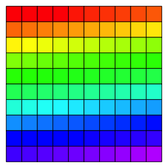

```r
scales::show_col(SelectColor("ET"), labels = FALSE)
```

```r
ET <- ReadET(ET_file = "b0140.cov")
b0140.color <- ET %>%
  select(POS, coverage) %>%
  mutate(ET.color = SelectColor(color_type = "ET", prefix = "0x")[ceiling(coverage)])
b0140.color
```

```
#> # A tibble: 246 × 3
#>     POS coverage ET.color
#>   <dbl>    <dbl> <chr>
#> 1     1     44.7 0x00ff1c
#> 2     2     81.6 0x001cff
#> 3     3     92.8 0x6a00ff
#> 4     4     98.5 0xb300ff
#> # … with 242 more rows
```

## Color assignment based on AlphaFold pLDDT score

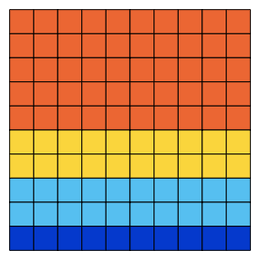

```r
scales::show_col(SelectColor("alphafold"), labels = FALSE)
```

Extract pLDDT score from pdb file, then assign color.

```r
pLDDT <- GetpLDDT("b0140.pdb", chain = "A")
b0140.color <- b0140.color %>%
  left_join(pLDDT) %>%
  mutate(pLDDT.color = SelectColor(color_type = "alphafold", prefix = "0x")[ceiling(pLDDT)])
b0140.color
```

```
#> # A tibble: 246 × 6
#>     POS coverage ET.color chain pLDDT pLDDT.color
#>   <dbl>    <dbl> <chr>    <chr> <dbl> <chr>
#> 1     1     44.7 0x00ff1c A      45.3 0xf17c42
#> 2     2     81.6 0x001cff A      55.4 0xfcdb4b
#> 3     3     92.8 0x6a00ff A      60.2 0xfcdb4b
#> 4     4     98.5 0xb300ff A      63.2 0xfcdb4b
#> # … with 242 more rows
```

```r
custom.color <- tibble(POS = c(139, 141), color = c("red", "cyan"))
```

## Generate Pymol session.

Combine pymol commands in string vector then run PymolExecuteAndSave() to execute the commands.

Load pdb file or pymol session.

```r
pymol.cmd <- PymolLoadFile("b0140.pdb")
```

Replicate protein b0140 and rename to ET, pLDDT, and custom. Pymol code can be chained into the cmd vector, and they will be ran sequentially.

```r
pymol.cmd <- c(pymol.cmd,
               "set_name b0140, ET",
               "copy pLDDT, ET",
               "copy custom_color, ET")
```

Color all atoms to white.

```r
pymol.cmd <- c(pymol.cmd,
               PymolColorChainSingleColor(color = "white"))
```

Color different protein objects by ET, pLDDT and custom color.

```r
pymol.cmd <- c(pymol.cmd,
               PymolColorChainByResidue(chain = "A", position = b0140.color$POS,
                                        color = b0140.color$ET.color,
                                        object = "ET"),
               PymolColorChainByResidue(chain = "A", position = b0140.color$POS,
                                        color = b0140.color$pLDDT.color,
                                        object = "pLDDT"),
               PymolColorChainByResidue(chain = "A", position = custom.color$POS,
                                        color = custom.color$color,
                                        object = "custom_color"))
```

Select residue 139 and 141 as a selection in pymol. Then show them as spheres in custom_color object.

```r
pymol.cmd <- c(pymol.cmd,
               PymolSelectResidues("A", position = c(139, 141),
                                   selection_name = "highlight"),
               "show spheres, custom_color and highlight")
```

Turn on grid view mode and sequence view. Ray a figure.

```r
pymol.cmd <- c(pymol.cmd,
               "set seq_view, 1",
               "set grid_mode, 1",
               "cmd._cmd._draw(cmd._COb)", # This pymol cmd is necessary for png to work with grid view in pymol batch mode.
               "png b0140.png, width=5cm, height=5cm, dpi=300, ray=1")
```

Execute Pymol commands and generate pymol session.

```r
PymolExecuteAndSave(pymol_cmd = pymol.cmd, output_file = "b0140_color.pse")
```

```
#> [1] "PSE file written"
```

Here is the image that was just produce for the pymol session.

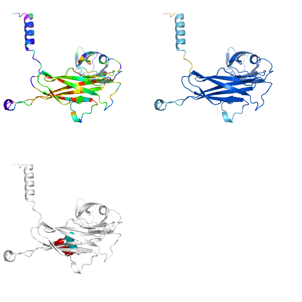